# CyTOF data analysis

## Dimensionality reduction

In this section, we will show an example of how to use R to create an interpretable representation of the samples in a CyTOF dataset. The idea is to “featurize” each sample in a useful way: in this analysis, we will partition the receptor space into 200 elements and use as features the fraction of cells in each sample which fall into each element of the partition. This gives us a count matrix with the number of cells in each sample falling into each element of the partition, and we use correspondence analysis to get a low-dimensional representation of this matrix.

To get some intuition into the procedure, note that if the elements of the partition were all of the same size, the Euclidean distance between the vectors containing the fraction of each sample falling in each element of the partition would be a discrete approximation of the L2 divergence between distributions. We will use k-means to create the partition, which means that the elements of the partition will not be of the same size, but we can think of it as a variation on the L2 divergence which upweights regions of receptor space which have higher average density.

First we load the required packages and read in our data.

```r
set.seed(0)
library(flowCore)
library(flexclust)
```

```r
library(ade4)
library(stringr)
library(viridis)
library(ggrepel)
library(ggplot2)
fs = readRDS("../cytof_stims/flow_list_asinh.rds")
expdata = readRDS("../cytof_stims/expdata.rds")
```

We do not want to use the results from donors 1 and 4, so we exclude them from the dataset.

```r
# exclude experiments 1 and 4
exp14 = which(expdata$Exp %in% c("Exp1", "Exp4"))
fs =  fs[-exp14]
expdata = expdata[-exp14,]
```

Next we rename some of the variables (this is just for so the plots have the right labels).

```r
expdata$Stim = as.character(expdata$Stim)
expdata$Stim[expdata$Stim == "uns"] = "unstimulated"
expdata$Stim[expdata$Stim == "magic"] = "IL12/IL15/IL18"
expdata$Donor = sapply(expdata$Exp, function(x) str_replace(x, "Exp", "Donor "))
```

Finally, we exclude CD4 and KIR2DL5 for technical reasons, and we exclude the functional markers for the purpose of this analysis. The same analysis can also be performed with the functional markers included.

```r
excludedMarkers = c("CD4", "KIR2DL5")
functionalMarkers = c("INFg", "TRAIL", "MIP1b", "GranzymeB", "CD107a", "GM.CSF", "TNFa", "Perforin")
fs = lapply(fs, function(x) x[,!(colnames(x) %in% excludedMarkers)])
fs = lapply(fs, function(x) x[,!(colnames(x) %in% functionalMarkers)])
```

Next we down-sample the cells so that when we perform k-means we are not over-weighting samples which have larger numbers of cells. We chose to downsample to 500 purely to save time, but increasing this number has almost no effect on the outcome.

```r
sampledCells = lapply(fs, function(x) x[sample(nrow(x), 500), ])
sampledCells = Reduce(rbind, sampledCells)
```

Next we perform k-means on the downsampled cells.

```r
nclust = 200
out.km = kmeans(sampledCells, centers = nclust, iter.max = 50)
out.fc = as.kcca(out.km, sampledCells)
```

Finally, we assign each of the cells in the full data set to one of the clusters and count how many cells correspond to each cluster. This gives us a count matrix called cluster.sizes.

```r
full.clusters = lapply(fs, function(x) predict(out.fc, newdata = x))
cluster.sizes = t(sapply(full.clusters, function(x) {
    sizes = table(x)
    sizesLong = sizes[as.character(1:nclust)]
    sizesLong[is.na(sizesLong)] = 0
    return(sizesLong)
}))
rownames(cluster.sizes)= rownames(expdata)
```

Finally, we can perform correspondence analysis and make some plots. The first thing to look at is the scree plot which shows us the fraction of the inertia explained by each axis.

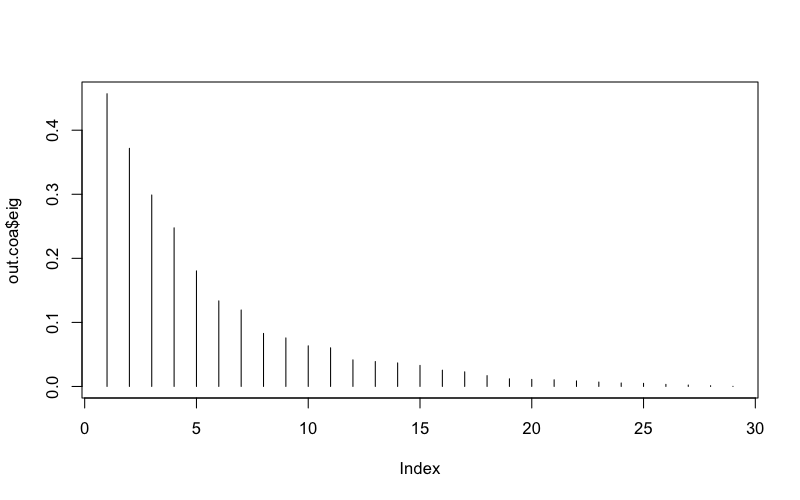

```r
out.coa = dudi.coa(cluster.sizes, scannf = FALSE, nf = 4)
plot(out.coa$eig, type = 'h')
```

Next we can look at the projections of the sample points onto the principal axes.

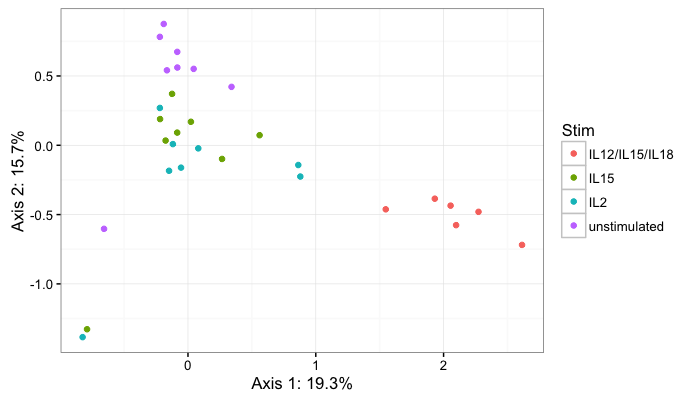

```r
axis1percent = round(out.coa$eig[1] / sum(out.coa$eig) * 100, digits = 1)
axis2percent = round(out.coa$eig[2] / sum(out.coa$eig) * 100, digits = 1)
axis3percent = round(out.coa$eig[3] / sum(out.coa$eig) * 100, digits = 1)
(p1 = ggplot(data.frame(out.coa$li, expdata)) +
    geom_point(aes(x = Axis1, y = Axis2, color = Stim)) +
        xlab(paste("Axis 1: ", axis1percent, "%", sep = "")) +
        ylab(paste("Axis 2: ", axis2percent, "%", sep = "")))
```

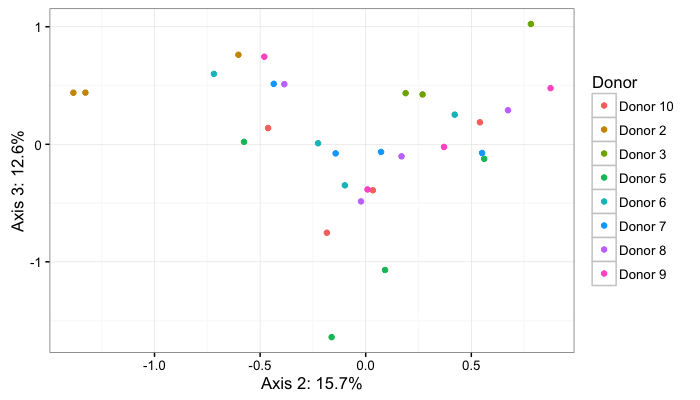

```r
ggplot(data.frame(out.coa$li, expdata)) +
    geom_point(aes(x = Axis2, y = Axis3, color = Donor)) +
    xlab(paste("Axis 2: ", axis2percent, "%", sep = "")) +
    ylab(paste("Axis 3: ", axis3percent, "%", sep = ""))
```

To get an idea of whether the axes are easily interpretable in terms of a single receptor, we can look at the correlation between the cluster centers and the axes.

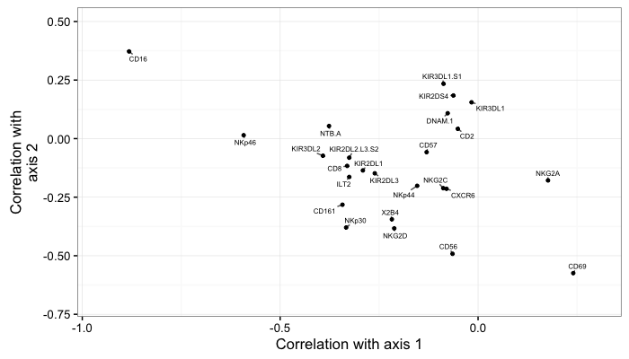

```r
cors = cor(out.fc@centers, out.coa$co)
cors = data.frame(cors)
cors$name = rownames(cors)
(p2 = ggplot(cors, aes(x = Comp1, y = Comp2, label = name)) +
    geom_text_repel( size = 2) + geom_point(size = 1) +
        ylim(c(-.7, .5)) + xlim(c(-.95, .3)) +
            xlab("Correlation with axis 1") + ylab("Correlation with\naxis 2"))
```

We see from the plot above that CD16 and CD69 are fairly strongly associated with the first and second axes, respectively. To validate this, we plot the projections of the clusters onto the principal plane, coloring the clusters by their average intensity of CD16 or CD69.

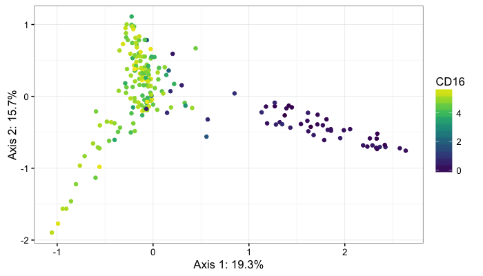

```r
(p3 = ggplot(data.frame(out.coa$co, out.fc@centers)) +
    geom_point(aes(x = Comp1, y = Comp2, color = CD16)) + scale_color_viridis() +
    xlab(paste("Axis 1: ", axis1percent, "%", sep = "")) +
    ylab(paste("Axis 2: ", axis2percent, "%", sep = "")))
```

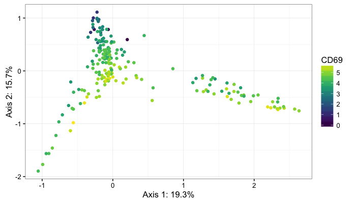

```r
(p4 = ggplot(data.frame(out.coa$co, out.fc@centers)) +
    geom_point(aes(x = Comp1, y = Comp2, color = CD69)) + scale_color_viridis() +
    xlab(paste("Axis 1: ", axis1percent, "%", sep = "")) +
    ylab(paste("Axis 2: ", axis2percent, "%", sep = "")))
```

Next we can look at the results of the same analysis with the functional markers included.

We re-read in the data:

```r
set.seed(0)
fs = readRDS("../cytof_stims/flow_list_asinh.rds")
expdata = readRDS("../cytof_stims/expdata.rds")
# exclude experiments 1 and 4
exp14 = which(expdata$Exp %in% c("Exp1", "Exp4"))
fs =  fs[-exp14]
expdata = expdata[-exp14,]
expdata$Stim = as.character(expdata$Stim)
expdata$Stim[expdata$Stim == "magic"] = "IL12/IL15/IL18"
expdata$Stim[expdata$Stim == "uns"] = "unstimulated"
expdata$Donor = sapply(expdata$Exp, function(x) str_replace(x, "Exp", "Donor "))

excludedMarkers = c("CD4", "KIR2DL5")
fs = lapply(fs, function(x) x[,!(colnames(x) %in% excludedMarkers)])
```

Then we downsample, perform k means, and make the cluster size matrix.

```r
sampledCells = lapply(fs, function(x) x[sample(nrow(x), 500), ])
sampledCells = Reduce(rbind, sampledCells)
nclust = 200
out.km = kmeans(sampledCells, centers = nclust, iter.max = 50)
out.fc = as.kcca(out.km, sampledCells)
full.clusters = lapply(fs, function(x) predict(out.fc, newdata = x))
cluster.sizes = t(sapply(full.clusters, function(x) {
    sizes = table(x)
    sizesLong = sizes[as.character(1:nclust)]
    sizesLong[is.na(sizesLong)] = 0
    return(sizesLong)
}))
rownames(cluster.sizes)= rownames(expdata)
```

And finally, we again perform correspondence analysis and make some plots.

```r
out.coa = dudi.coa(cluster.sizes, scannf = FALSE, nf = 6)
```

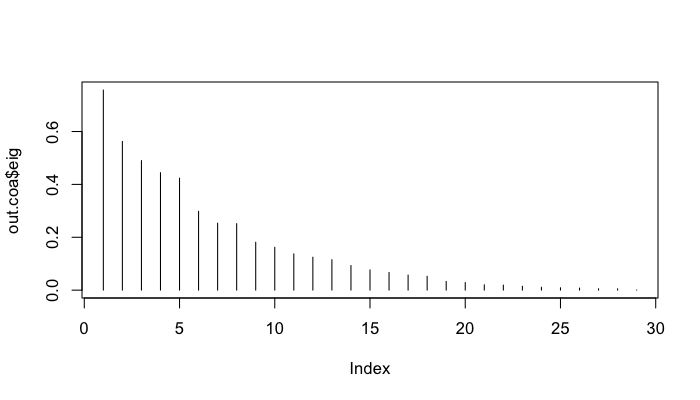

```r
cors = cor(out.fc@centers, out.coa$co)
cors = data.frame(cors)
cors$name = rownames(cors)
axis1percent = round(out.coa$eig[1] / sum(out.coa$eig) * 100, digits = 1)
axis2percent = round(out.coa$eig[2] / sum(out.coa$eig) * 100, digits = 1)
plot(out.coa$eig, type = 'h')
```

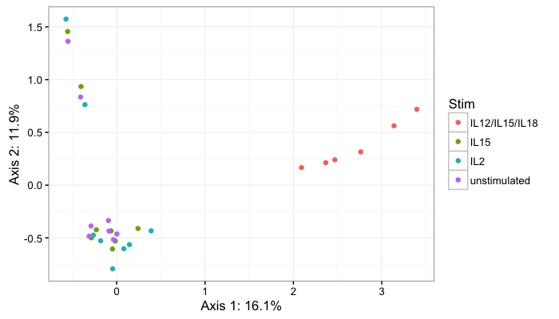

```r
(p1 = ggplot(data.frame(out.coa$li, expdata)) +
    geom_point( aes(x = Axis1, y = Axis2, color = Stim)) +
        xlab(paste("Axis 1: ", axis1percent, "%", sep = "")) +
            ylab(paste("Axis 2: ", axis2percent, "%", sep = "")))
```

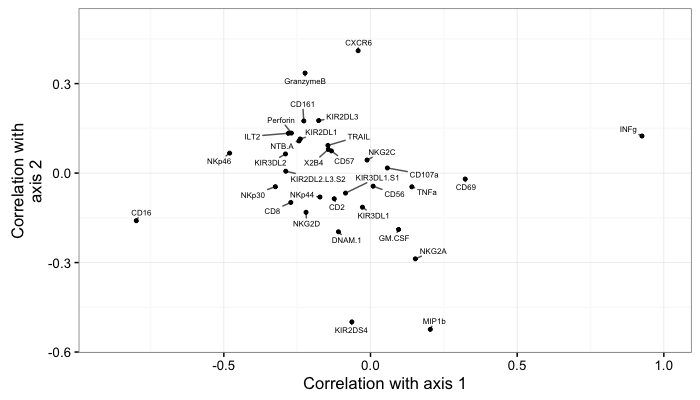

```r
(p2 = ggplot(cors, aes(x = Comp1, y = Comp2, label = name)) +
    geom_text_repel(size = 2) + geom_point(size = 1) +
        xlim(c(-.9,1)) + ylim(c(-.55, .5)) +
            xlab("Correlation with axis 1") + ylab("Correlation with\naxis 2"))
```

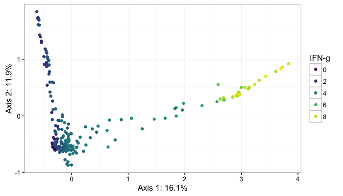

```r
(p3 = ggplot(data.frame(out.coa$co, out.fc@centers)) +
    geom_point(aes(x = Comp1, y = Comp2, color = INFg)) +
        scale_color_viridis(guide = guide_legend(title = "IFN-g"))  +
            xlab(paste("Axis 1: ", axis1percent, "%", sep = "")) +
                ylab(paste("Axis 2: ", axis2percent, "%", sep = "")))
```

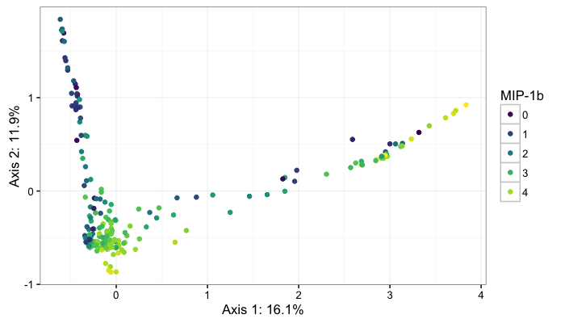

```r
(p4 = ggplot(data.frame(out.coa$co, out.fc@centers)) +
    geom_point(aes(x = Comp1, y = Comp2, color = MIP1b)) +
        scale_color_viridis(guide = guide_legend(title = "MIP-1b")) +
            xlab(paste("Axis 1: ", axis1percent, "%", sep = "")) +
                ylab(paste("Axis 2: ", axis2percent, "%", sep = "")))
```

## Testing

We can use the features from the previous section (the number or fraction of cells in each sample falling in each section of the partitioned receptor space) to do testing. Here we apply the Friedman-Rafsky test, which is a two-sample multivariate test based on distances. For each sample, we have a vector containing the proportion of cells falling in each section of the space, and we use as a distance on the samples the distance between those vectors. After computing these distances, we compute a minimum spanning tree over the samples using the distances between the proportion vectors. The Friedman-Rafsky test statistic is the number of pure edges in this tree (the number of edges connecting two samples in the same class), and the null distribution is approximated by permutation.

First we get the cluster proportions from the cluster sizes and define the function that will do our test for us.

```r
library(igraph)
cluster.proportions = t(apply(cluster.sizes, 1, function(x) x / sum(x)))


fr_test = function(types) {
    d = dist(cluster.proportions[expdata$Stim %in% types,])
    g = graph.adjacency(as.matrix(d), weighted = TRUE, mode = "undirected", diag = FALSE)
    mst = minimum.spanning.tree(g)
    el = get.edgelist(mst)

    typelist = el
    typelist[,1] = expdata[el[,1], "Stim"]
    typelist[,2] = expdata[el[,2], "Stim"]
    npure = sum(apply(typelist, 1, function(x) x[1] == x[2]))

    niter = 1999
    npureNull = numeric(niter)
    permexpdata = subset(expdata, expdata$Stim %in% types)
    for(i in 1:niter) {
        for(ex in unique(permexpdata$Exp)) {
            idx = which(permexpdata$Exp == ex)
            permexpdata[idx,"Stim"] = sample(permexpdata[idx, "Stim"], size = length(idx))
        }
        typelistPerm = el
        typelistPerm[,1] = permexpdata[el[,1], "Stim"]
        typelistPerm[,2] = permexpdata[el[,2], "Stim"]
        npurePerm = sum(apply(typelistPerm, 1, function(x) x[1] == x[2]))
        npureNull[i] = npurePerm
    }


    qplot(npureNull, geom = "histogram")
    mean(c(npureNull, npure) >= npure)
    return(list(pval = mean(c(npureNull, npure) >= npure),
                null = npureNull, npure = npure))
}
```

Then we can use this function to test every pair of conditions.

```r
fr_test(c("unstimulated", "IL12/IL15/IL18"))$pval
```

```
## [1] 0.019
```

```r
fr_test(c("unstimulated", "IL15"))$pval
```

```
## [1] 0.0085
```

```r
fr_test(c("unstimulated", "IL2"))$pval
```

```
## [1] 0.027
```

```r
fr_test(c("IL12/IL15/IL18", "IL15"))$pval
```

```
## [1] 0.0295
```

```r
fr_test(c("IL12/IL15/IL18", "IL2"))$pval
```

```
## [1] 0.015
```

```r
fr_test(c("IL15", "IL2"))$pval
```

```
## [1] 0.231
```